# Inferring Breast Cancer Risk with Genetic Data

Julian McClellan

8/25/2020

# Overview

Using **E**fficient **L**ocal **A**ncestry **I**nference (**ELAI**) we will estimate SNP allele dosages for a sample of African Americans using source populations from West Africa and Northern/Western Europe.

Combining the ELAI results with the cancer statuses of the sample individuals, we will fit a model to infer breast cancer risk.

# Data

- 3686 individuals in the sample cohort
- 173 individuals in the reference panel

## Cohort

| status | n |
| --- | --- |
| cancer | 1657 |
| control | 2028 |
| unknown | 1 |

## Panel

| ancestry | n |
| --- | --- |
| Northern/Western Europe | 85 |
| West Africa (Nigeria) | 88 |

# Transformations

Both the cohort files and panel files end up as bimbam format files for use in ELAI.

## Sample preprocessing

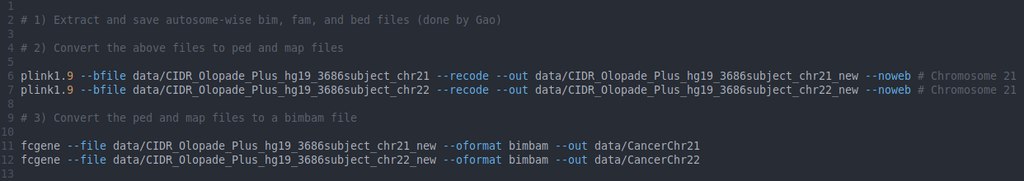

## Reference Preprocessing

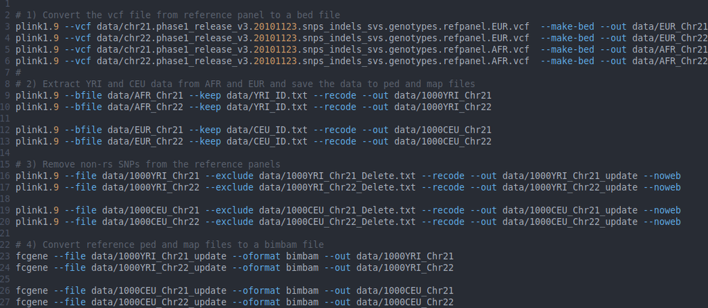

## Bimbam Processing

- For the `*geno.txt` files for the cohort and panel, the number of SNPs must be put on the 2nd row.

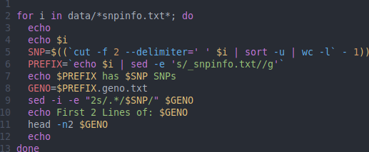

## Bimbam Processing

- For the sample position files the chromsome ID is added.

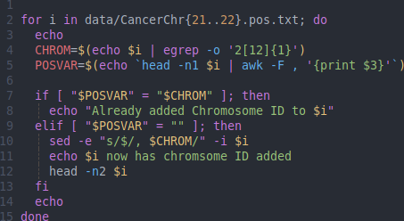

## Bimbam Processing

- For the reference `*geno.txt` files, we add an `"="` after the number of individuals because these genotypes are *phased*, that is, we can identify which chromosome the genotypes’ alleles are from.

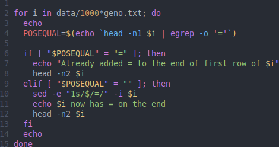

# Ancestry Inference

ELAI uses a two-layer Hidden Markov model to infer local ancestry of admixed individuals.

Given our sample of African Americans . . .

- African Americans have 2 source populations:
  - West Africans
  - Northern/Western Europeans
- These 2 source populations began to mix ~10 generations ago.

These facts inform our final ELAI command.

## ELAI Command

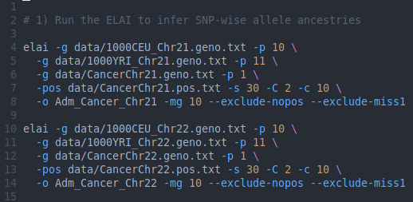

## ELAI Output | Dosage

- A file containing a table with dimensions $(S, M, N)$, where:
  - $S$ corresponds to the number of source populations (`2`)
  - $M$ to the number of SNPs present in all position and genotype files.

    | chromosome | SNPs |
    | --- | --- |
    | 21 | 20352 |
    | 22 | 21244 |

  - $N$ to the number of admixed individuals in the sample (`3686`).
- For a given $s$, $m$, and $n$ in the file we will see the expected number of alleles from the $s$th source population for $m$th marker for $n$th individual. (allele dosage $\in[0,2]$)

## ELAI Output | SNP Info

- A file showing information on the SNPs.
  - `rsID`
  - `minor allele`
  - `major allele`
  - `minor allele frequency`
  - `major allele frequency`
  - `position`

# Cancer Risk Inference

By combining elements of the ELAI input and output, we can create a file suitable for cancer risk inference, a $N \times M$ file where individual cancer statuses and rsIDs of SNPs can be identified.

So for a given chromsome with $M$ SNPs we model cancer status as:

$$cancer\_status \sim allele\_dosage_{1} + \ \cdot\cdot\cdot \ + allele\_dosage_{M}$$

I have chosen West African allele dosages for use as predictor variables.

## Logistic LASSO Regression

- LASSO has the nice property of zeroing out coefficients.
  - Can allow a simpler model that focuses on the most relevant SNP predictors.
- Model selection chooses the model with highest ROC using:
  - Scaled data (all dosages have `SD` of `1`).
  - `90%` of the data is utilized for training, with `10%` reserved to assess model performance.
  - 5 fold cross validation repeated 50 times across 100 possible lambda values (equidistant on log scale from `.001` to `100`).

Models

1. 20352 SNPs from Chromosome 21
2. 21244 SNPs from Chromosome 22
3. 41596 SNPs from Chromosomes 21 + 22 (separate ELAI runs)

## Performance | Final Models | Held Out Test Data

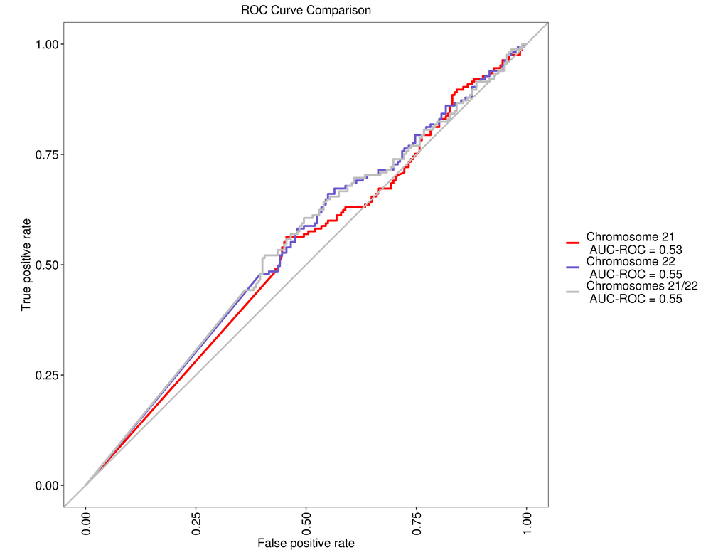

## Performance | ROC Bootstrap 95% CIs

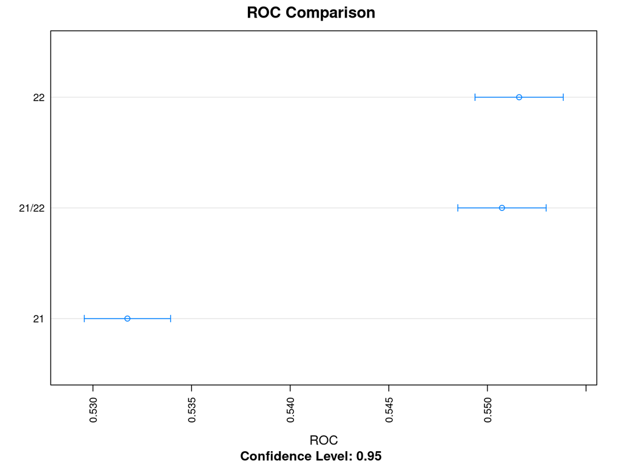

## Lambda Parameters

| model | lambda | SNPs |
| --- | --- | --- |
| 21 | 0.01451 | 20352 |
| 22 | 0.01150 | 21244 |
| 21/22 | 0.01831 | 41596 |

## Coefficients | Chromsome 21

| coef | snp | position |
| --- | --- | --- |
| -0.01901 | rs460014 | 16091441 |
| -0.01696 | rs78005009 | 15304554 |
| -0.01322 | rs11700564 | 47437318 |
| -0.01264 | rs11088237 | 34450578 |
| -0.00993 | rs62214175 | 34450283 |
| -0.00558 | rs20521 | 34447507 |
| -0.00538 | rs73900179 | 34448295 |
| -0.00429 | rs724070 | 34431840 |
| -0.00398 | rs2838808 | 46621106 |
| -0.00356 | rs2838810 | 46623323 |
| -0.00203 | rs8128481 | 16121835 |
| -0.00143 | rs1556318 | 46619840 |
| -0.00008 | rs77099066 | 46619183 |
| 0.58151 | (Intercept) | NA |

## Coefficients | Chromsome 21

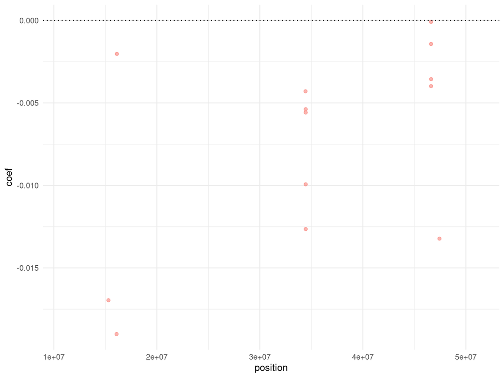

## Coefficients | Chromsome 22

| coef | snp | position |
| --- | --- | --- |
| -0.04025 | rs7284605 | 31220604 |
| -0.03033 | rs4263223 | 47944269 |
| -0.02467 | rs62235942 | 31220817 |
| -0.02421 | rs4823643 | 47830034 |
| -0.01831 | rs1984519 | 46876483 |
| -0.01169 | rs522537 | 27636486 |
| -0.00857 | rs56066153 | 29927243 |
| -0.00751 | rs4823510 | 48437078 |
| -0.00725 | rs1990502 | 17573272 |
| -0.00673 | rs5762042 | 27636606 |
| -0.00375 | rs5763304 | 29930064 |
| -0.00238 | rs5763301 | 29929627 |
| -0.00226 | rs8135828 | 29929239 |
| -0.00221 | rs9616897 | 51083118 |
| -0.00161 | rs12159217 | 17573915 |
| -0.00116 | rs2302141 | 29925284 |
| -0.00025 | rs9613942 | 29935704 |
| -0.00023 | rs10460765 | 47944748 |
| -0.00005 | rs2157157 | 48416711 |
| -0.00001 | rs4823044 | 29924825 |
| 0.00000 | rs11090807 | 48417356 |
| 0.00000 | rs4040041 | 51078251 |
| 0.00000 | rs117239733 | 29931504 |
| 0.00000 | rs999458 | 29932438 |
| 0.00000 | rs130489 | 47944428 |
| 0.90995 | (Intercept) | NA |

## Coefficients | Chromsome 22

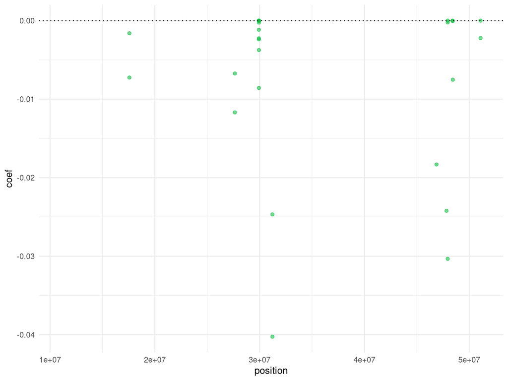

## Coefficients | Chromsome 21/22

| coef | snp | chromosome | position |
| --- | --- | --- | --- |
| -0.00185 | rs724070 | 21 | 34431840 |
| -0.00182 | rs11088237 | 21 | 34450578 |
| -0.00123 | rs62214175 | 21 | 34450283 |
| -0.00106 | rs20521 | 21 | 34447507 |
| -0.00068 | rs73900179 | 21 | 34448295 |
| -0.00063 | rs78005009 | 21 | 15304554 |
| -0.03927 | rs7284605 | 22 | 31220604 |
| -0.02662 | rs4263223 | 22 | 47944269 |
| -0.02357 | rs4823643 | 22 | 47830034 |
| -0.01880 | rs62235942 | 22 | 31220817 |
| -0.01044 | rs1984519 | 22 | 46876483 |
| -0.00546 | rs522537 | 22 | 27636486 |
| -0.00505 | rs56066153 | 22 | 29927243 |
| -0.00328 | rs2302141 | 22 | 29925284 |
| -0.00276 | rs5762042 | 22 | 27636606 |
| -0.00229 | rs5763304 | 22 | 29930064 |
| -0.00145 | rs5763301 | 22 | 29929627 |
| -0.00136 | rs8135828 | 22 | 29929239 |
| -0.00017 | rs737976 | 22 | 29913272 |
| -0.00016 | rs10460765 | 22 | 47944748 |
| -0.00009 | rs4823044 | 22 | 29924825 |
| -0.00002 | rs2188120 | 22 | 29920819 |
| -0.00002 | rs1049534 | 22 | 29908072 |
| 0.00000 | rs130489 | 22 | 47944428 |
| 0.00000 | rs117239733 | 22 | 29931504 |
| 0.00000 | rs737975 | 22 | 29908849 |
| 0.00000 | rs4608625 | 22 | 29912430 |
| 0.00000 | rs12161054 | 22 | 29912885 |
| 0.74095 | (Intercept) | NA | NA |

## Coefficients | Chromsome 21/22

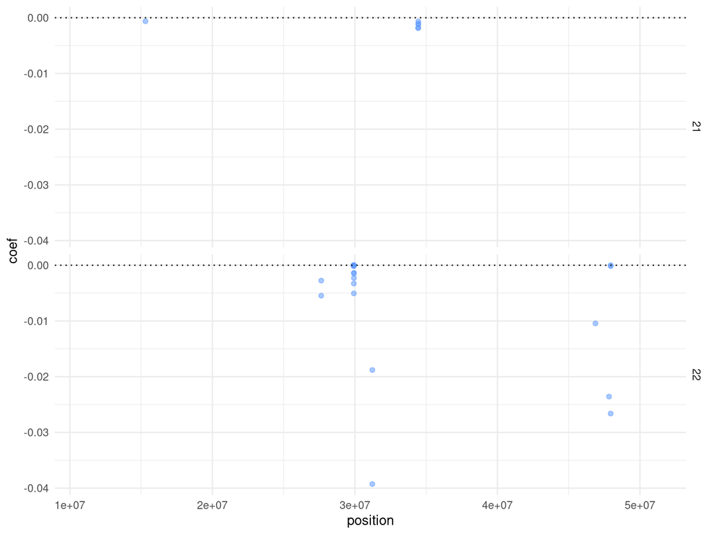

## Coefficients | Overlap?

[output not shown]

## Coefficients | Overlap?

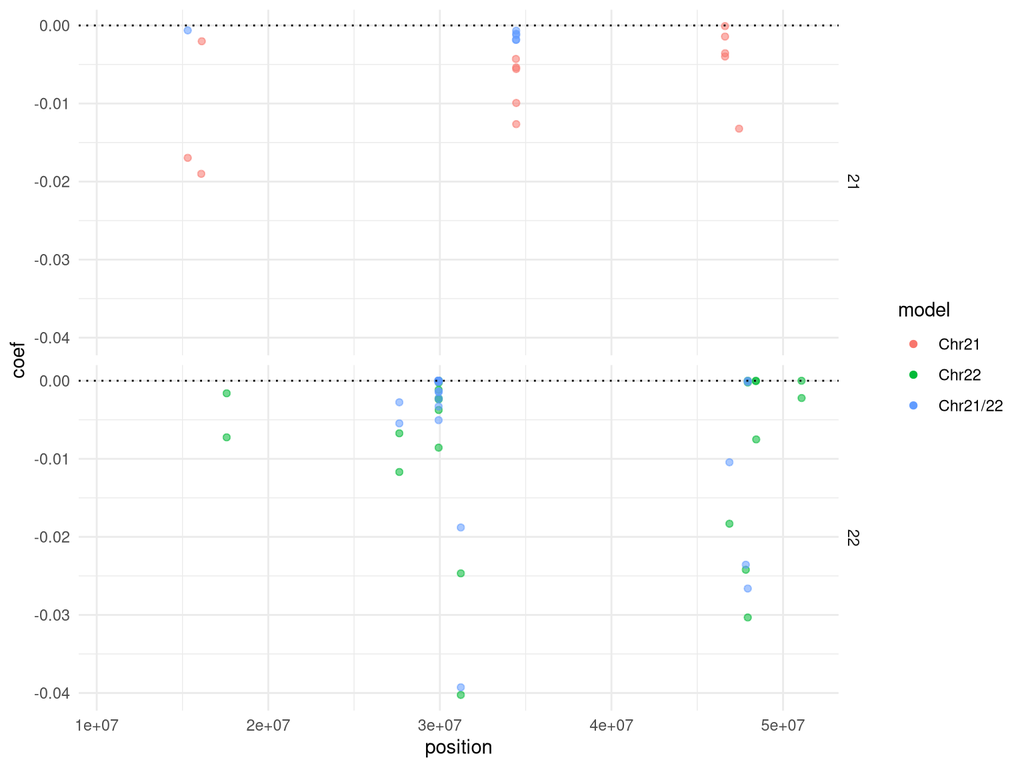

## Coefficients | Overlap?

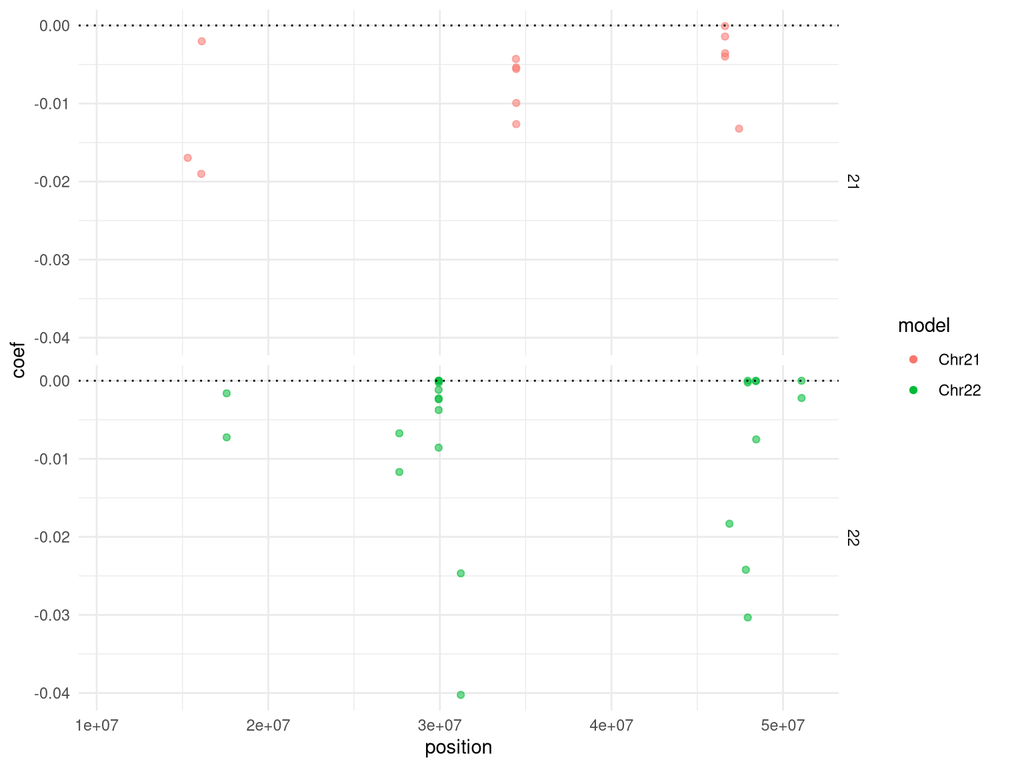

# Potential Adjustments: Transformation

- Could do file format transformations without `fcgene`.
  - `plink1.9` offers bimbam output that differs slightly from `fcgene's`, but should still work in ELAI.

## Potential Adjustments: Ancestry Inference

- ELAI author recommends averaging results over different mixture generation numbers.
  - Could also weight by uncertainty.
- Joint model fitting: Running additional EM steps on source *and* admixed samples is also recommended by the author.
- Could increase # of EM steps above 30.
- ELAI can be run with SNPs from multiple chromosomes simultaneously.
  - Some further adjustment of ELAI input position files would be necessary.

## Potential Adjustments: Cancer Risk Inference

- Various different models, feature selection, parameter tuning schemes, etc.
- Utilize selected SNPs from LASSO in plain logistic regression (to get SE’s for coefficients)